# Data Exploration

Author

Sara Parrish

Published

Oct 3, 2024

# Dataset 1: Bureau of Transportation Statistics

## Airline On-Time Statistics and Delay Causes for PNS

https://www.transtats.bts.gov/OT_Delay/OT_DelayCause1.asp?20=E

- The following disclaimer can be found on the website: “A flight is considered delayed when it arrived 15 or more minutes [later] than the schedule (see definitions in Frequently Asked Questions). Delayed minutes are calculated for delayed flights only. Data presented summarizes arriving flights only. When multiple causes are assigned to one delayed flight, each cause is prorated based on delayed minutes it is responsible for. The displayed numbers are rounded and may not add up to the total.”
- I began by reading the data in and inspecting the organization.

```r
library(knitr)

BTSdelays <- read.csv("BTS_Delays.csv")
```

```r
kable(head(BTSdelays))
```

| year | month | carrier | carrier_name | airport | airport_name | arr_flights | arr_del15 | carrier_ct | weather_ct | nas_ct | security_ct | late_aircraft_ct | arr_cancelled | arr_diverted | arr_delay | carrier_delay | weather_delay | nas_delay | security_delay | late_aircraft_delay |
| --- | --- | --- | --- | --- | --- | --- | --- | --- | --- | --- | --- | --- | --- | --- | --- | --- | --- | --- | --- | --- |
| 2024 | 7 | 9E | Endeavor Air Inc. | PNS | Pensacola, FL: Pensacola International | 10 | 4 | 2.00 | 0.00 | 1.00 | 0 | 1.00 | 0 | 0 | 199 | 88 | 0 | 30 | 0 | 81 |
| 2024 | 7 | AA | American Airlines Network | PNS | Pensacola, FL: Pensacola International | 216 | 112 | 26.02 | 1.54 | 23.62 | 0 | 60.82 | 6 | 0 | 9049 | 1926 | 106 | 1118 | 0 | 5899 |
| 2024 | 7 | C5 | CommuteAir LLC dba CommuteAir | PNS | Pensacola, FL: Pensacola International | 93 | 29 | 6.33 | 0.34 | 11.59 | 0 | 10.74 | 6 | 1 | 2827 | 359 | 77 | 595 | 0 | 1796 |
| 2024 | 7 | DL | Delta Air Lines Network | PNS | Pensacola, FL: Pensacola International | 258 | 85 | 47.35 | 1.54 | 13.38 | 0 | 22.73 | 17 | 0 | 7145 | 4635 | 125 | 868 | 0 | 1517 |
| 2024 | 7 | F9 | Frontier Airlines | PNS | Pensacola, FL: Pensacola International | 55 | 9 | 2.45 | 1.42 | 1.70 | 0 | 3.43 | 1 | 0 | 467 | 62 | 88 | 56 | 0 | 261 |
| 2024 | 7 | MQ | Envoy Air | PNS | Pensacola, FL: Pensacola International | 97 | 33 | 4.28 | 0.59 | 11.89 | 0 | 16.25 | 0 | 0 | 1561 | 179 | 23 | 407 | 0 | 952 |

```r
dim(BTSdelays)
```

```
[1] 1366   21
```

```r
knitr::kable(tail(BTSdelays))
```

|  | year | month | carrier | carrier_name | airport | airport_name | arr_flights | arr_del15 | carrier_ct | weather_ct | nas_ct | security_ct | late_aircraft_ct | arr_cancelled | arr_diverted | arr_delay | carrier_delay | weather_delay | nas_delay | security_delay | late_aircraft_delay |
| --- | --- | --- | --- | --- | --- | --- | --- | --- | --- | --- | --- | --- | --- | --- | --- | --- | --- | --- | --- | --- | --- |
| 1361 | 2010 | 1 | DL | Delta Air Lines Inc. | PNS | Pensacola, FL: Pensacola International | 165 | 19 | 6.98 | 0.98 | 6.38 | 0.00 | 4.66 | 9 | 0 | 894 | 317 | 171 | 207 | 0 | 199 |
| 1362 | 2010 | 1 | EV | Atlantic Southeast Airlines | PNS | Pensacola, FL: Pensacola International | 74 | 19 | 12.39 | 0.00 | 2.46 | 1.85 | 2.30 | 1 | 0 | 1104 | 754 | 0 | 40 | 192 | 118 |
| 1363 | 2010 | 1 | FL | AirTran Airways Corporation | PNS | Pensacola, FL: Pensacola International | 92 | 19 | 4.54 | 0.62 | 4.44 | 0.00 | 9.41 | 3 | 1 | 934 | 95 | 77 | 132 | 0 | 630 |
| 1364 | 2010 | 1 | MQ | American Eagle Airlines Inc. | PNS | Pensacola, FL: Pensacola International | 155 | 30 | 10.05 | 2.19 | 10.13 | 0.00 | 7.62 | 2 | 0 | 1307 | 417 | 83 | 308 | 0 | 499 |
| 1365 | 2010 | 1 | XE | ExpressJet Airlines Inc. | PNS | Pensacola, FL: Pensacola International | 115 | 19 | 7.59 | 0.25 | 7.51 | 0.00 | 3.65 | 0 | 1 | 846 | 431 | 10 | 215 | 0 | 190 |
| 1366 | 2010 | 1 | YV | Mesa Airlines Inc. | PNS | Pensacola, FL: Pensacola International | 35 | 5 | 2.00 | 1.00 | 2.00 | 0.00 | 0.00 | 2 | 0 | 240 | 53 | 146 | 41 | 0 | 0 |

- So we have 1366 entries, with 21 columns, going back to January of 2010.
- Following are the provided definitions of the variables.

| Variable | Definition |
| --- | --- |
| year | YYYY format |
| month | MM format (1-12) |
| carrier | Code assigned by assigned by US DOT to identify a unique airline carrier. |
| carrier_name | Unique airline (carrier) is defined as one holding and reporting under the same DOT certificate regardless of its Code, Name, or holding company/corporation. |
| airport | A three character alpha-numeric code issued by the U.S. Department of Transportation which is the official designation of the airport. |
| airport_name | a place from which aircraft operate that usually has paved runways and maintenance facilities and often serves as a terminal |
| arr_flights | Arrival Flights |
| arr_del15 | Arrival Delay Indicator, 15 Minutes or More Arrival delay equals the difference of the actual arrival time minus the scheduled arrival time. A flight is considered on-time when it arrives less than 15… |
| carrier_ct | Carrier Count for airline cause of delay |
| weather_ct | Weather Count for airline cause of delay |
| nas_ct | NAS (National Air System) Count for airline cause of delay |
| security_ct | Security County for airline cause of delay |
| late_aircraft_ct | Late Aircraft Delay Count for airline cause of delay |
| arr_cancelled | flight cancelled |
| arr_diverted | flight diverted |
| arr_delay | Difference in minutes between scheduled and actual arrival time. Early arrivals show negative numbers. |
| carrier_delay | Carrier Delay, in Minutes |
| weather_delay | Weather Delay, in Minutes |
| nas_delay | National Air System Delay, in Minutes |
| security_delay | Security Delay, in Minutes |
| late_aircraft_delay | Late Aircraft Delay, in Minutes |

- This data set is composed of data reported by domestic carriers monthly to the Bureau of Transportation Statistics (BTS). The BTS has data on all domestic airports, but the Pensacola Airport was chosen for this review. Each monthly report by the carrier includes information on flights arriving at the selected airport, not on departures.
- Below I view and remove NA inputs.

```r
library(tidyr)
colSums(is.na(BTSdelays))
```

```
               year               month             carrier        carrier_name
                  0                   0                   0                   0
            airport        airport_name         arr_flights           arr_del15
                  0                   0                   3                   5
         carrier_ct          weather_ct              nas_ct         security_ct
                  3                   3                   3                   3
   late_aircraft_ct       arr_cancelled        arr_diverted           arr_delay
                  3                   3                   3                   3
      carrier_delay       weather_delay           nas_delay      security_delay
                  3                   3                   3                   3
late_aircraft_delay
                  3
```

```r
print(BTSdelays[rowSums(is.na(BTSdelays)) > 0, ])
```

```
    year month carrier             carrier_name airport
119 2023    10      YV       Mesa Airlines Inc.     PNS
222 2023     1      YV       Mesa Airlines Inc.     PNS
525 2020    12      UA United Air Lines Network     PNS
594 2020     4      YX         Republic Airline     PNS
932 2016    12      OO    SkyWest Airlines Inc.     PNS
                              airport_name arr_flights arr_del15 carrier_ct
119 Pensacola, FL: Pensacola International          NA        NA         NA
222 Pensacola, FL: Pensacola International          NA        NA         NA
525 Pensacola, FL: Pensacola International          NA        NA         NA
594 Pensacola, FL: Pensacola International           6        NA          0
932 Pensacola, FL: Pensacola International           1        NA          0
    weather_ct nas_ct security_ct late_aircraft_ct arr_cancelled arr_diverted
119         NA     NA          NA               NA            NA           NA
222         NA     NA          NA               NA            NA           NA
525         NA     NA          NA               NA            NA           NA
594          0      0           0                0             6            0
932          0      0           0                0             1            0
    arr_delay carrier_delay weather_delay nas_delay security_delay
119        NA            NA            NA        NA             NA
222        NA            NA            NA        NA             NA
525        NA            NA            NA        NA             NA
594         0             0             0         0              0
932         0             0             0         0              0
    late_aircraft_delay
119                  NA
222                  NA
525                  NA
594                   0
932                   0
```

```r
BTSdelays1 <-na.omit(BTSdelays)
unique(BTSdelays1$carrier)
```

```
 [1] "9E" "AA" "C5" "DL" "F9" "MQ" "NK" "OH" "UA" "WN" "YX" "OO" "YV" "ZW" "G7"
[16] "EV" "AX" "FL" "XE"
```

- Below I group data by carrier and get the total arrived flights and average arrival delay. I want to look into the average arrival delays by carrier.

```r
library(dplyr)
carrier_summary <- BTSdelays1 %>%
  group_by(carrier) %>%
  summarize(
    total_flights = sum(arr_flights),
    avg_arr_delay = sum(arr_delay)/total_flights
  )

print(carrier_summary)
```

```
# A tibble: 19 × 3
   carrier total_flights avg_arr_delay
   <chr>           <dbl>         <dbl>
 1 9E               1207          8.11
 2 AA               8052         22.3
 3 AX                 24          2.83
 4 C5               2742         15.5
 5 DL              36425          8.19
 6 EV              16566         11.8
 7 F9               1562         12.7
 8 FL               4160          7.31
 9 G7                160         11.8
10 MQ              24019          9.45
11 NK               2148         18.8
12 OH              14275         14.8
13 OO               1998         13.1
14 UA               1860         21.6
15 WN              16974         10.1
16 XE               3656          9.11
17 YV               7694         13.8
18 YX               3071          7.44
19 ZW                953         12.8
```

```r
carrier_count <- BTSdelays1 %>%
  count(carrier)
print(carrier_count)
```

```
   carrier   n
1       9E  21
2       AA  93
3       AX   2
4       C5  44
5       DL 175
6       EV 129
7       F9  76
8       FL  47
9       G7   7
10      MQ 148
11      NK  34
12      OH  80
13      OO  80
14      UA  47
15      WN 129
16      XE  24
17      YV 118
18      YX  69
19      ZW  38
```

- Since there are quite a few carriers with much less data, I remove some with the fewest reported months.

```r
library(psych)
carrier_stats <- describe(carrier_count$n)
print(carrier_stats)
```

```
   vars  n  mean    sd median trimmed   mad min max range skew kurtosis    se
X1    1 19 71.63 49.58     69   69.65 51.89   2 175   173 0.45    -0.98 11.38
```

- The median falls fairly close to the mean, so I chose it as the cutoff.

```r
carrier_summary1 <- carrier_summary%>%
  left_join(carrier_count, by= "carrier", suffix = c("", "_count"))

print(carrier_summary1)
```

```
# A tibble: 19 × 4
   carrier total_flights avg_arr_delay     n
   <chr>           <dbl>         <dbl> <int>
 1 9E               1207          8.11    21
 2 AA               8052         22.3     93
 3 AX                 24          2.83     2
 4 C5               2742         15.5     44
 5 DL              36425          8.19   175
 6 EV              16566         11.8    129
 7 F9               1562         12.7     76
 8 FL               4160          7.31    47
 9 G7                160         11.8      7
10 MQ              24019          9.45   148
11 NK               2148         18.8     34
12 OH              14275         14.8     80
13 OO               1998         13.1     80
14 UA               1860         21.6     47
15 WN              16974         10.1    129
16 XE               3656          9.11    24
17 YV               7694         13.8    118
18 YX               3071          7.44    69
19 ZW                953         12.8     38
```

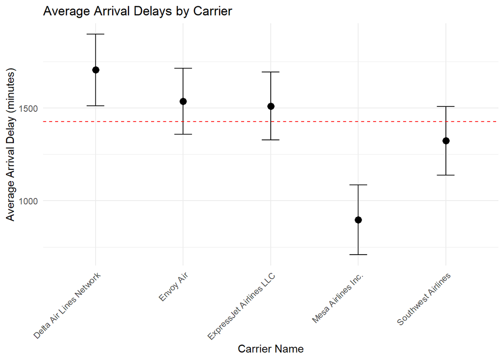

```r
library(ggplot2)

carrier_summary_ci <- BTSdelays1 %>%
  group_by(carrier) %>%
  summarise(
    carrier_name = first(carrier_name),
    avg_arr_delay = mean(arr_delay, na.rm = TRUE),
    n = n(),
    sd_arr_delay = sd(arr_delay, na.rm = TRUE)
  ) %>%
  filter(n>100) %>%
  mutate(
    lower_ci = avg_arr_delay - qt(0.975, df = n - 1) * sd_arr_delay / sqrt(n),
    upper_ci = avg_arr_delay + qt(0.975, df = n - 1) * sd_arr_delay / sqrt(n)
  )


filtered_carriers <- BTSdelays1 %>%
  group_by(carrier) %>%
  filter(n() > 100)

total_mean_delay_filtered <- mean(filtered_carriers$arr_delay)

ggplot(carrier_summary_ci, aes(x = carrier_name, y = avg_arr_delay)) +
  geom_point(size = 3) +
  geom_errorbar(aes(ymin = lower_ci, ymax = upper_ci), width = 0.2) +
  geom_hline(yintercept = total_mean_delay_filtered, linetype = "dashed", color = "red") +
  labs(title = "Average Arrival Delays by Carrier",
       x = "Carrier Name",
       y = "Average Arrival Delay (minutes)") +
  theme_minimal()+
  theme(axis.text.x = element_text(angle = 45, hjust = 1))
```

- From January 2010 to July 2024, there are 175 months of data. The only airline that has been consistently operating through PNS over this time frame is Delta, so this visualization filtered for any airline with over 100 months of data.
- With some quick research, Envoy is a [subsidiary](https://www.envoyair.com/#:~:text=Envoy%20Air%20Inc.%20is%20a%20wholly%2Downed%20subsidiary%20of%20American%20Airlines%20Group) of American Airlines, Mesa is [partnered](https://www.mesa-air.com/#:~:text=As%20part%20of%20this%20collaboration,travel%20options%20across%20the%20globe.) with United, and ExpressJet closed its doors in 2022.

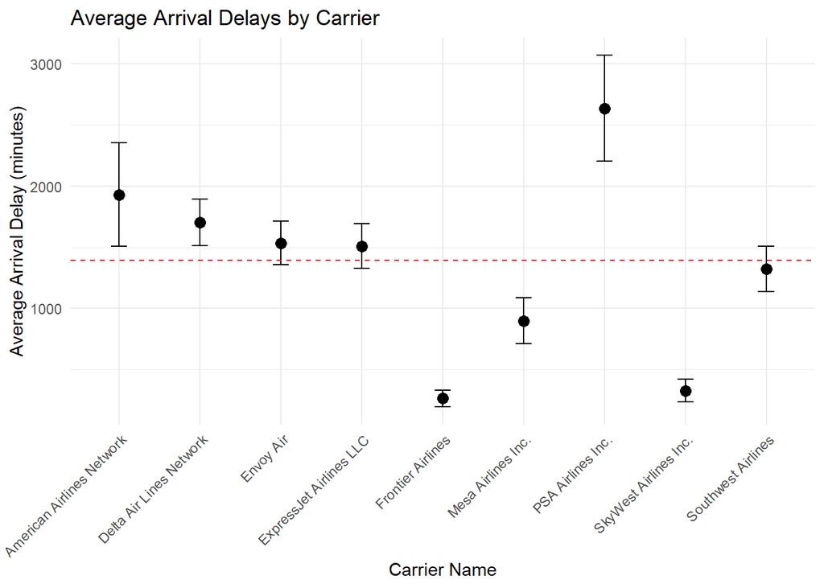

```r
carrier_summary_ci <- BTSdelays1 %>%
  group_by(carrier) %>%
  summarise(
    carrier_name = first(carrier_name),
    avg_arr_delay = mean(arr_delay, na.rm = TRUE),
    n = n(),
    sd_arr_delay = sd(arr_delay, na.rm = TRUE)
  ) %>%
  filter(n>70) %>%
  mutate(
    lower_ci = avg_arr_delay - qt(0.975, df = n - 1) * sd_arr_delay / sqrt(n),
    upper_ci = avg_arr_delay + qt(0.975, df = n - 1) * sd_arr_delay / sqrt(n)
  )

filtered_carriers <- BTSdelays1 %>%
  group_by(carrier) %>%
  filter(n() > 70)

total_mean_delay_filtered <- mean(filtered_carriers$arr_delay)

ggplot(carrier_summary_ci, aes(x = carrier_name, y = avg_arr_delay)) +
  geom_point(size = 3) +
  geom_errorbar(aes(ymin = lower_ci, ymax = upper_ci), width = 0.2) +
  geom_hline(yintercept = total_mean_delay_filtered, linetype = "dashed", color = "red") +
  labs(title = "Average Arrival Delays by Carrier",
       x = "Carrier Name",
       y = "Average Arrival Delay (minutes)") +
  theme_minimal()+
  theme(axis.text.x = element_text(angle = 45, hjust = 1))
```

# Dataset 2: Flight Delay and Cancellation Data Set

## Also From the BTS

https://www.kaggle.com/datasets/patrickzel/flight-delay-and-cancellation-dataset-2019-2023?resource=download

- This data set appears to be from the same database as the previous data set, but includes an additional 11 attributes to include scheduled and actual arrival and departure time.

```r
Kaggledelays <- read.csv("Kaggle_flights.csv")
knitr::kable(head(Kaggledelays))
```

| FL_DATE | AIRLINE | AIRLINE_DOT | AIRLINE_CODE | DOT_CODE | FL_NUMBER | ORIGIN | ORIGIN_CITY | DEST | DEST_CITY | CRS_DEP_TIME | DEP_TIME | DEP_DELAY | TAXI_OUT | WHEELS_OFF | WHEELS_ON | TAXI_IN | CRS_ARR_TIME | ARR_TIME | ARR_DELAY | CANCELLED | CANCELLATION_CODE | DIVERTED | CRS_ELAPSED_TIME | ELAPSED_TIME | AIR_TIME | DISTANCE | DELAY_DUE_CARRIER | DELAY_DUE_WEATHER | DELAY_DUE_NAS | … |
| --- | --- | --- | --- | --- | --- | --- | --- | --- | --- | --- | --- | --- | --- | --- | --- | --- | --- | --- | --- | --- | --- | --- | --- | --- | --- | --- | --- | --- | --- | --- |
| 2019-01-09 | United Air Lines Inc. | United Air Lines Inc.: UA | UA | 19977 | 1562 | FLL | Fort Lauderdale, FL | EWR | Newark, NJ | 1155 | 1151 | -4 | 19 | 1210 | 1443 | 4 | 1501 | 1447 | -14 | 0 |  | 0 | 186 | 176 | 153 | 1065 | NA | NA | NA | … |
| 2022-11-19 | Delta Air Lines Inc. | Delta Air Lines Inc.: DL | DL | 19790 | 1149 | MSP | Minneapolis, MN | SEA | Seattle, WA | 2120 | 2114 | -6 | 9 | 2123 | 2232 | 38 | 2315 | 2310 | -5 | 0 |  | 0 | 235 | 236 | 189 | 1399 | NA | NA | NA | … |
| 2022-07-22 | United Air Lines Inc. | United Air Lines Inc.: UA | UA | 19977 | 459 | DEN | Denver, CO | MSP | Minneapolis, MN | 954 | 1000 | 6 | 20 | 1020 | 1247 | 5 | 1252 | 1252 | 0 | 0 |  | 0 | 118 | 112 | 87 | 680 | NA | NA | NA | … |
| 2023-03-06 | Delta Air Lines Inc. | Delta Air Lines Inc.: DL | DL | 19790 | 2295 | MSP | Minneapolis, MN | SFO | San Francisco, CA | 1609 | 1608 | -1 | 27 | 1635 | 1844 | 9 | 1829 | 1853 | 24 | 0 |  | 0 | 260 | 285 | 249 | 1589 | 0 | 0 | 24 | … |
| 2020-02-23 | Spirit Air Lines | Spirit Air Lines: NK | NK | 20416 | 407 | MCO | Orlando, FL | DFW | Dallas/Fort Worth, TX | 1840 | 1838 | -2 | 15 | 1853 | 2026 | 14 | 2041 | 2040 | -1 | 0 |  | 0 | 181 | 182 | 153 | 985 | NA | NA | NA | … |
| 2019-07-31 | Southwest Airlines Co. | Southwest Airlines Co.: WN | WN | 19393 | 665 | DAL | Dallas, TX | OKC | Oklahoma City, OK | 1010 | 1237 | 147 | 15 | 1252 | 1328 | 3 | 1110 | 1331 | 141 | 0 |  | 0 | 60 | 54 | 36 | 181 | 141 | 0 | 0 | … |

```r
dim(Kaggledelays)
```

```
[1] 3000000      32
```

- This data set is much larger with 3 million rows and 32 columns.

```r
names(Kaggledelays)
```

```
 [1] "FL_DATE"                 "AIRLINE"
 [3] "AIRLINE_DOT"             "AIRLINE_CODE"
 [5] "DOT_CODE"                "FL_NUMBER"
 [7] "ORIGIN"                  "ORIGIN_CITY"
 [9] "DEST"                    "DEST_CITY"
[11] "CRS_DEP_TIME"            "DEP_TIME"
[13] "DEP_DELAY"               "TAXI_OUT"
[15] "WHEELS_OFF"              "WHEELS_ON"
[17] "TAXI_IN"                 "CRS_ARR_TIME"
[19] "ARR_TIME"                "ARR_DELAY"
[21] "CANCELLED"               "CANCELLATION_CODE"
[23] "DIVERTED"                "CRS_ELAPSED_TIME"
[25] "ELAPSED_TIME"            "AIR_TIME"
[27] "DISTANCE"                "DELAY_DUE_CARRIER"
[29] "DELAY_DUE_WEATHER"       "DELAY_DUE_NAS"
[31] "DELAY_DUE_SECURITY"      "DELAY_DUE_LATE_AIRCRAFT"
```

```r
unique_airlines <- Kaggledelays %>%
  summarise(unique_airlines = n_distinct(AIRLINE))
print(unique_airlines)
```

```
  unique_airlines
1              18
```

```r
unique_dest <- Kaggledelays %>%
  summarise(unique_dest = n_distinct(DEST))
print(unique_dest)
```

```
  unique_dest
1         380
```

```r
dest_count <- Kaggledelays %>%
  count(DEST) %>%
  filter(DEST %in% c("PNS", "MIA"))
print(dest_count)
```

```
  DEST     n
1  MIA 42015
2  PNS  5489
```

- Given this data set is working with 380 unique destinations, it makes sense that it is also comprised of 18 different airlines. There is an issue when it comes to computation with this data set. Three million lines can be quite much for 8GB of RAM.

```r
KaggleMiami <- Kaggledelays %>%
  filter(DEST == "MIA")
dim(KaggleMiami)
```

```
[1] 42015    32
```

```r
KagglePensacola <- Kaggledelays %>%
  filter(DEST == "PNS")
dim(KagglePensacola)
```

```
[1] 5489   32
```

- Nice. Manageable.

```r
airline_summaryMIA <- KaggleMiami %>%
  na.omit() %>%
  group_by(AIRLINE_CODE) %>%
  summarize(
    avg_arr_delay = mean(ARR_DELAY),
    avg_airtime = mean(AIR_TIME),
    n = n()
  )

airline_summaryPNS <- KagglePensacola %>%
  na.omit() %>%
  group_by(AIRLINE_CODE) %>%
  summarize(
    avg_arr_delay = mean(ARR_DELAY),
    avg_airtime = mean(AIR_TIME),
    n = n()
  )

carrier_counts_MIA <- KaggleMiami %>%
  count(AIRLINE_CODE)

carrier_counts_PNS <- KagglePensacola %>%
  count(AIRLINE_CODE)

library(summarytools)

descr(carrier_counts_MIA$n)
```

```
Descriptive Statistics
carrier_counts_MIA$n
N: 12

                           n
----------------- ----------
             Mean    3501.25
          Std.Dev    6092.73
              Min      13.00
               Q1     527.00
           Median    1633.50
               Q3    3186.50
              Max   22178.00
              MAD    1862.89
              IQR    2108.25
               CV       1.74
         Skewness       2.34
      SE.Skewness       0.64
         Kurtosis       4.39
          N.Valid      12.00
        Pct.Valid     100.00
```

```r
descr(carrier_counts_PNS$n)
```

```
Descriptive Statistics
carrier_counts_PNS$n
N: 12

                          n
----------------- ---------
             Mean    457.42
          Std.Dev    407.51
              Min     98.00
               Q1    136.50
           Median    290.50
               Q3    762.50
              Max   1216.00
              MAD    242.41
              IQR    540.00
               CV      0.89
         Skewness      0.74
      SE.Skewness      0.64
         Kurtosis     -1.18
          N.Valid     12.00
        Pct.Valid    100.00
```

```r
print(airline_summaryMIA)
```

```
# A tibble: 12 × 4
   AIRLINE_CODE avg_arr_delay avg_airtime     n
   <chr>                <dbl>       <dbl> <int>
 1 9E                    59.3        132.     3
 2 AA                    80.2        149.  4053
 3 AS                    46.3        331.     9
 4 B6                    83.9        179.   320
 5 DL                    60.8        136.   760
 6 F9                    85.1        148.   415
 7 MQ                    63.5        103.   947
 8 NK                    67.2        151.   329
 9 UA                    64.3        155.   547
10 WN                    55.8        133.   477
11 YV                    51.7        142.    10
12 YX                    63.7        120.   251
```

```r
print(airline_summaryPNS)
```

```
# A tibble: 12 × 4
   AIRLINE_CODE avg_arr_delay avg_airtime     n
   <chr>                <dbl>       <dbl> <int>
 1 AA                    69.5        82.8   142
 2 DL                    69.8        49.8   141
 3 EV                    58.1        77.8    29
 4 F9                    35.2       141.     11
 5 MQ                    44.5        89.7    97
 6 NK                    56.6        76.2    36
 7 OH                    69.5        95.5   211
 8 OO                    71.4       108.     34
 9 UA                   109.         79.4    34
10 WN                    46.2        76.3   179
11 YV                    71.5        76.6    72
12 YX                    44.3       119.     30
```

- I considered visualizing this but then decided tracking arrival delays as a function of airtime would be more interesting.

```r
#Filter for n
#MIA - n > 372
carrier_counts_MIA <- KaggleMiami %>%
  count(AIRLINE_CODE) %>%
  filter(n >= 3186)

print(carrier_counts_MIA)
```

```
  AIRLINE_CODE     n
1           AA 22178
2           DL  3811
3           MQ  5355
```

```r
KaggleMiami1 <- KaggleMiami %>%
  filter(AIRLINE_CODE %in% carrier_counts_MIA$AIRLINE_CODE & ARR_DELAY >= 15)


#PNS - n > 54

carrier_counts_PNS <- KagglePensacola %>%
  count(AIRLINE_CODE) %>%
  filter(n >= 762)

print(carrier_counts_PNS)
```

```
  AIRLINE_CODE    n
1           DL 1216
2           OH 1088
3           WN  932
```

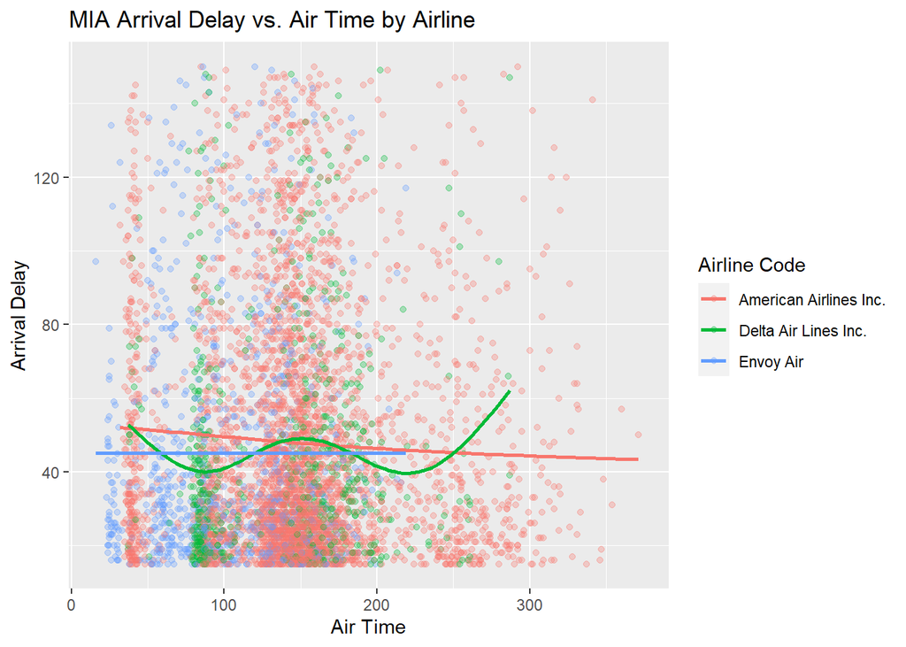

```r
KagglePensacola1 <- KagglePensacola %>%
  filter(AIRLINE_CODE %in% carrier_counts_PNS$AIRLINE_CODE & ARR_DELAY >= 15)




library(ggplot2)
ggplot(KaggleMiami1, aes(x = AIR_TIME, y = ARR_DELAY, color = AIRLINE)) +
  geom_point(alpha = 0.3) +
  geom_smooth(se=FALSE) +
  labs(
    title = "MIA Arrival Delay vs. Air Time by Airline",
    x = "Air Time",
    y = "Arrival Delay",
    color = "Airline Code") +
  ylim(NA, 150)
```

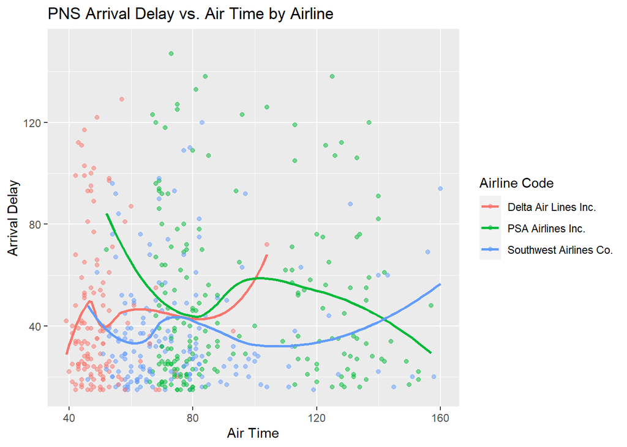

```r
ggplot(KagglePensacola1, aes(x = AIR_TIME, y = ARR_DELAY, color = AIRLINE)) +
  geom_point(alpha = 0.5) +
  geom_smooth(se = FALSE) +
  labs(
    title = "PNS Arrival Delay vs. Air Time by Airline",
    x = "Air Time",
    y = "Arrival Delay",
    color = "Airline Code") +
  ylim(NA, 150)
```

- PSA Airlines is a [subsidiary](https://www.psaairlines.com/about/#:~:text=PSA%20is%20a%20proud%20wholly%20owned%20subsidiary%20of%20American%20Airlines) of American Airlines.
- Kinda useless but maybe slightly better. There doesn’t appear to be an obvious relationship between air time and arrival delay. It may be beneficial to look into other relationships, potentially between type of delay and total delay.
- Further exploration in a relationship between air time and arrival delay could be interesting. This data set also provides the opportunity to investigate some other variables such as taxi time or time of day of the flight. While this data set is fairly large, interesting insight can be extracted from it.